# Part I - Ford Go Bike Dataset Exploration

## Introduction

> The selected dataset holds information on the individual usage of a bike-sharing service from the greater San Fransisco Bay area during the month of February in the year 2019.

## Preliminary Wrangling

```python
# import all packages and set plots to be embedded inline
import numpy as np
import pandas as pd
import matplotlib.pyplot as plt
import seaborn as sb

%matplotlib inline
```

```python
# Load the ford go bike dataset
bikeData = pd.read_csv('./data/201902-fordgobike-tripdata.csv')
```

```python
# Dataset shape
bikeData.shape
```

```
(183412, 16)
```

```python
# Dataset data types
bikeData.dtypes
```

```
duration_sec                 int64
start_time                  object
end_time                    object
start_station_id           float64
start_station_name          object
start_station_latitude     float64
start_station_longitude    float64
end_station_id             float64
end_station_name            object
end_station_latitude       float64
end_station_longitude      float64
bike_id                      int64
user_type                   object
member_birth_year          float64
member_gender               object
bike_share_for_all_trip     object
dtype: object
```

```python
# Dataset head
bikeData.head(10)
```

|  | duration_sec | start_time | end_time | start_station_id | start_station_name | start_station_latitude | start_station_longitude | end_station_id | end_station_name | end_station_latitude | end_station_longitude | bike_id | user_type | member_birth_year | member_gender | bike_share_for_all_trip |
| --- | --- | --- | --- | --- | --- | --- | --- | --- | --- | --- | --- | --- | --- | --- | --- | --- |
| 0 | 52185 | 2019-02-28 17:32:10.1450 | 2019-03-01 08:01:55.9750 | 21.0 | Montgomery St BART Station (Market St at 2nd St) | 37.789625 | -122.400811 | 13.0 | Commercial St at Montgomery St | 37.794231 | -122.402923 | 4902 | Customer | 1984.0 | Male | No |
| 1 | 42521 | 2019-02-28 18:53:21.7890 | 2019-03-01 06:42:03.0560 | 23.0 | The Embarcadero at Steuart St | 37.791464 | -122.391034 | 81.0 | Berry St at 4th St | 37.775880 | -122.393170 | 2535 | Customer | NaN | NaN | No |
| 2 | 61854 | 2019-02-28 12:13:13.2180 | 2019-03-01 05:24:08.1460 | 86.0 | Market St at Dolores St | 37.769305 | -122.426826 | 3.0 | Powell St BART Station (Market St at 4th St) | 37.786375 | -122.404904 | 5905 | Customer | 1972.0 | Male | No |
| 3 | 36490 | 2019-02-28 17:54:26.0100 | 2019-03-01 04:02:36.8420 | 375.0 | Grove St at Masonic Ave | 37.774836 | -122.446546 | 70.0 | Central Ave at Fell St | 37.773311 | -122.444293 | 6638 | Subscriber | 1989.0 | Other | No |
| 4 | 1585 | 2019-02-28 23:54:18.5490 | 2019-03-01 00:20:44.0740 | 7.0 | Frank H Ogawa Plaza | 37.804562 | -122.271738 | 222.0 | 10th Ave at E 15th St | 37.792714 | -122.248780 | 4898 | Subscriber | 1974.0 | Male | Yes |
| 5 | 1793 | 2019-02-28 23:49:58.6320 | 2019-03-01 00:19:51.7600 | 93.0 | 4th St at Mission Bay Blvd S | 37.770407 | -122.391198 | 323.0 | Broadway at Kearny | 37.798014 | -122.405950 | 5200 | Subscriber | 1959.0 | Male | No |
| 6 | 1147 | 2019-02-28 23:55:35.1040 | 2019-03-01 00:14:42.5880 | 300.0 | Palm St at Willow St | 37.317298 | -121.884995 | 312.0 | San Jose Diridon Station | 37.329732 | -121.901782 | 3803 | Subscriber | 1983.0 | Female | No |
| 7 | 1615 | 2019-02-28 23:41:06.7660 | 2019-03-01 00:08:02.7560 | 10.0 | Washington St at Kearny St | 37.795393 | -122.404770 | 127.0 | Valencia St at 21st St | 37.756708 | -122.421025 | 6329 | Subscriber | 1989.0 | Male | No |
| 8 | 1570 | 2019-02-28 23:41:48.7900 | 2019-03-01 00:07:59.7150 | 10.0 | Washington St at Kearny St | 37.795393 | -122.404770 | 127.0 | Valencia St at 21st St | 37.756708 | -122.421025 | 6548 | Subscriber | 1988.0 | Other | No |
| 9 | 1049 | 2019-02-28 23:49:47.6990 | 2019-03-01 00:07:17.0250 | 19.0 | Post St at Kearny St | 37.788975 | -122.403452 | 121.0 | Mission Playground | 37.759210 | -122.421339 | 6488 | Subscriber | 1992.0 | Male | No |

```python
# Dataset description
bikeData.describe()
```

|  | duration_sec | start_station_id | start_station_latitude | start_station_longitude | end_station_id | end_station_latitude | end_station_longitude | bike_id | member_birth_year |
| --- | --- | --- | --- | --- | --- | --- | --- | --- | --- |
| count | 183412.000000 | 183215.000000 | 183412.000000 | 183412.000000 | 183215.000000 | 183412.000000 | 183412.000000 | 183412.000000 | 175147.000000 |
| mean | 726.078435 | 138.590427 | 37.771223 | -122.352664 | 136.249123 | 37.771427 | -122.352250 | 4472.906375 | 1984.806437 |
| std | 1794.389780 | 111.778864 | 0.099581 | 0.117097 | 111.515131 | 0.099490 | 0.116673 | 1664.383394 | 10.116689 |
| min | 61.000000 | 3.000000 | 37.317298 | -122.453704 | 3.000000 | 37.317298 | -122.453704 | 11.000000 | 1878.000000 |
| 25% | 325.000000 | 47.000000 | 37.770083 | -122.412408 | 44.000000 | 37.770407 | -122.411726 | 3777.000000 | 1980.000000 |
| 50% | 514.000000 | 104.000000 | 37.780760 | -122.398285 | 100.000000 | 37.781010 | -122.398279 | 4958.000000 | 1987.000000 |
| 75% | 796.000000 | 239.000000 | 37.797280 | -122.286533 | 235.000000 | 37.797320 | -122.288045 | 5502.000000 | 1992.000000 |
| max | 85444.000000 | 398.000000 | 37.880222 | -121.874119 | 398.000000 | 37.880222 | -121.874119 | 6645.000000 | 2001.000000 |

```python
# Dataset info
bikeData.info()
```

```
<class 'pandas.core.frame.DataFrame'>
RangeIndex: 183412 entries, 0 to 183411
Data columns (total 16 columns):
 #   Column                   Non-Null Count   Dtype
---  ------                   --------------   -----
 0   duration_sec             183412 non-null  int64
 1   start_time               183412 non-null  object
 2   end_time                 183412 non-null  object
 3   start_station_id         183215 non-null  float64
 4   start_station_name       183215 non-null  object
 5   start_station_latitude   183412 non-null  float64
 6   start_station_longitude  183412 non-null  float64
 7   end_station_id           183215 non-null  float64
 8   end_station_name         183215 non-null  object
 9   end_station_latitude     183412 non-null  float64
 10  end_station_longitude    183412 non-null  float64
 11  bike_id                  183412 non-null  int64
 12  user_type                183412 non-null  object
 13  member_birth_year        175147 non-null  float64
 14  member_gender            175147 non-null  object
 15  bike_share_for_all_trip  183412 non-null  object
dtypes: float64(7), int64(2), object(7)
memory usage: 22.4+ MB
```

```python
# Find the sum of null data
bikeData.isnull().sum()
```

```
duration_sec                  0
start_time                    0
end_time                      0
start_station_id            197
start_station_name          197
start_station_latitude        0
start_station_longitude       0
end_station_id              197
end_station_name            197
end_station_latitude          0
end_station_longitude         0
bike_id                       0
user_type                     0
member_birth_year          8265
member_gender              8265
bike_share_for_all_trip       0
dtype: int64
```

```python
# Find duplicate data
bikeData.duplicated().sum()
```

```
0
```

```python
# Value counts
bikeData['member_gender'].value_counts()
```

```
Male      130651
Female     40844
Other       3652
Name: member_gender, dtype: int64
```

```python
# Value counts
bikeData['start_station_name'].value_counts()
```

```
Market St at 10th St                                         3904
San Francisco Caltrain Station 2  (Townsend St at 4th St)    3544
Berry St at 4th St                                           3052
Montgomery St BART Station (Market St at 2nd St)             2895
Powell St BART Station (Market St at 4th St)                 2760
                                                             ...
Willow St at Vine St                                            9
Parker Ave at McAllister St                                     7
Palm St at Willow St                                            4
21st Ave at International Blvd                                  4
16th St Depot                                                   2
Name: start_station_name, Length: 329, dtype: int64
```

```python
# Value counts
bikeData['end_station_name'].value_counts()
```

```
San Francisco Caltrain Station 2  (Townsend St at 4th St)    4857
Market St at 10th St                                         3973
Montgomery St BART Station (Market St at 2nd St)             3647
San Francisco Ferry Building (Harry Bridges Plaza)           3368
Powell St BART Station (Market St at 4th St)                 2997
                                                             ...
Parker Ave at McAllister St                                     9
Palm St at Willow St                                            7
16th St Depot                                                   6
21st Ave at International Blvd                                  6
Willow St at Vine St                                            5
Name: end_station_name, Length: 329, dtype: int64
```

```python
# Value counts
bikeData['user_type'].value_counts()
```

```
Subscriber    163544
Customer       19868
Name: user_type, dtype: int64
```

```python
# Value counts
bikeData['bike_share_for_all_trip'].value_counts()
```

```
No     166053
Yes     17359
Name: bike_share_for_all_trip, dtype: int64
```

```python
# Make a copy of the dataset to work on
tripsData = bikeData.copy()
```

```python
# Cleaning data
# Fix incorrect datatypes
tripsData['start_time'] = pd.to_datetime(tripsData['start_time'])
tripsData['end_time'] = pd.to_datetime(tripsData['end_time'])
tripsData['start_station_id'] = tripsData['start_station_id'].astype('str')
tripsData['end_station_id'] = tripsData['end_station_id'].astype('str')
tripsData['bike_id'] = tripsData['bike_id'].astype('str')
tripsData['user_type'] = tripsData['user_type'].astype('category')
tripsData['member_gender'] = tripsData['member_gender'].astype('category')

tripsData.info(show_counts=True)
```

```
<class 'pandas.core.frame.DataFrame'>
RangeIndex: 183412 entries, 0 to 183411
Data columns (total 16 columns):
 #   Column                   Non-Null Count   Dtype
---  ------                   --------------   -----
 0   duration_sec             183412 non-null  int64
 1   start_time               183412 non-null  datetime64[ns]
 2   end_time                 183412 non-null  datetime64[ns]
 3   start_station_id         183412 non-null  object
 4   start_station_name       183215 non-null  object
 5   start_station_latitude   183412 non-null  float64
 6   start_station_longitude  183412 non-null  float64
 7   end_station_id           183412 non-null  object
 8   end_station_name         183215 non-null  object
 9   end_station_latitude     183412 non-null  float64
 10  end_station_longitude    183412 non-null  float64
 11  bike_id                  183412 non-null  object
 12  user_type                183412 non-null  category
 13  member_birth_year        175147 non-null  float64
 14  member_gender            175147 non-null  category
 15  bike_share_for_all_trip  183412 non-null  object
dtypes: category(2), datetime64[ns](2), float64(5), int64(1), object(6)
memory usage: 19.9+ MB
```

```python
# Add more insightful columns to assist in more informed plots
# 1. Trip duration in minutes
# 2. Trip start date in dd-mm-yyyy format
# 3. Trip start hour, day and month

tripsData['duration_minute'] = tripsData['duration_sec']/60
tripsData['start_date'] = tripsData.start_time.dt.strftime('%d-%m-%Y')
tripsData['start_hour'] = tripsData.start_time.dt.strftime('%H')
tripsData['start_day'] = tripsData.start_time.dt.strftime('%A')
tripsData['start_month'] = tripsData.start_time.dt.strftime('%B')

tripsData.head()
```

|  | duration_sec | start_time | end_time | start_station_id | start_station_name | start_station_latitude | start_station_longitude | end_station_id | end_station_name | end_station_latitude | ... | bike_id | user_type | member_birth_year | member_gender | bike_share_for_all_trip | duration_minute | start_date | start_hour | start_day | start_month |
| --- | --- | --- | --- | --- | --- | --- | --- | --- | --- | --- | --- | --- | --- | --- | --- | --- | --- | --- | --- | --- | --- |
| 0 | 52185 | 2019-02-28 17:32:10.145 | 2019-03-01 08:01:55.975 | 21.0 | Montgomery St BART Station (Market St at 2nd St) | 37.789625 | -122.400811 | 13.0 | Commercial St at Montgomery St | 37.794231 | ... | 4902 | Customer | 1984.0 | Male | No | 869.750000 | 28-02-2019 | 17 | Thursday | February |
| 1 | 42521 | 2019-02-28 18:53:21.789 | 2019-03-01 06:42:03.056 | 23.0 | The Embarcadero at Steuart St | 37.791464 | -122.391034 | 81.0 | Berry St at 4th St | 37.775880 | ... | 2535 | Customer | NaN | NaN | No | 708.683333 | 28-02-2019 | 18 | Thursday | February |
| 2 | 61854 | 2019-02-28 12:13:13.218 | 2019-03-01 05:24:08.146 | 86.0 | Market St at Dolores St | 37.769305 | -122.426826 | 3.0 | Powell St BART Station (Market St at 4th St) | 37.786375 | ... | 5905 | Customer | 1972.0 | Male | No | 1030.900000 | 28-02-2019 | 12 | Thursday | February |
| 3 | 36490 | 2019-02-28 17:54:26.010 | 2019-03-01 04:02:36.842 | 375.0 | Grove St at Masonic Ave | 37.774836 | -122.446546 | 70.0 | Central Ave at Fell St | 37.773311 | ... | 6638 | Subscriber | 1989.0 | Other | No | 608.166667 | 28-02-2019 | 17 | Thursday | February |
| 4 | 1585 | 2019-02-28 23:54:18.549 | 2019-03-01 00:20:44.074 | 7.0 | Frank H Ogawa Plaza | 37.804562 | -122.271738 | 222.0 | 10th Ave at E 15th St | 37.792714 | ... | 4898 | Subscriber | 1974.0 | Male | Yes | 26.416667 | 28-02-2019 | 23 | Thursday | February |

5 rows × 21 columns

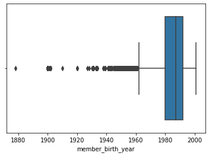

```python
# Check for outliers in birth year column
sb.boxplot(tripsData['member_birth_year'])
```

```python
# check for proportion of people born before 1960
pre_1960 = len(tripsData[tripsData['member_birth_year']<1960])
pre_1960_percent = pre_1960/len(tripsData)
print (f'{(pre_1960_percent*100):.2f}% of the population were born before 1960 and should ideally be treated as an issue given the data is for 2019')
```

```
2.26% of the population were born before 1960 and should ideally be treated as an issue given the data is for 2019
```

```python
# Check Age
# Add a new column calculating riders' age from 'member_birth_year'
tripsData['member_age'] = 2019 - tripsData['member_birth_year']
tripsData.describe()
```

|  | duration_sec | start_station_latitude | start_station_longitude | end_station_latitude | end_station_longitude | member_birth_year | duration_minute | member_age |
| --- | --- | --- | --- | --- | --- | --- | --- | --- |
| count | 183412.000000 | 183412.000000 | 183412.000000 | 183412.000000 | 183412.000000 | 175147.000000 | 183412.000000 | 175147.000000 |
| mean | 726.078435 | 37.771223 | -122.352664 | 37.771427 | -122.352250 | 1984.806437 | 12.101307 | 34.193563 |
| std | 1794.389780 | 0.099581 | 0.117097 | 0.099490 | 0.116673 | 10.116689 | 29.906496 | 10.116689 |
| min | 61.000000 | 37.317298 | -122.453704 | 37.317298 | -122.453704 | 1878.000000 | 1.016667 | 18.000000 |
| 25% | 325.000000 | 37.770083 | -122.412408 | 37.770407 | -122.411726 | 1980.000000 | 5.416667 | 27.000000 |
| 50% | 514.000000 | 37.780760 | -122.398285 | 37.781010 | -122.398279 | 1987.000000 | 8.566667 | 32.000000 |
| 75% | 796.000000 | 37.797280 | -122.286533 | 37.797320 | -122.288045 | 1992.000000 | 13.266667 | 39.000000 |
| max | 85444.000000 | 37.880222 | -121.874119 | 37.880222 | -121.874119 | 2001.000000 | 1424.066667 | 141.000000 |

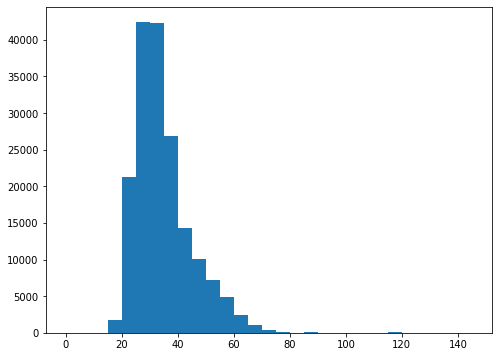

```python
# Find the outliers above 100 years old from the age column
plt.figure(figsize=[8, 6])
bins = np.arange(0, tripsData['member_age'].max()+5, 5)
plt.hist(tripsData['member_age'].dropna(), bins=bins)
```

```python
# Filter out outlier ages
# Set 'member_birth_year' and 'member_age' to integer instead of float type
tripsData = tripsData.query('member_age <= 70')
tripsData['member_birth_year'] = tripsData['member_birth_year'].astype('int')
tripsData['member_age'] = tripsData['member_age'].astype('int')
tripsData.info(show_counts=True)
```

```
<class 'pandas.core.frame.DataFrame'>
Int64Index: 174572 entries, 0 to 183411
Data columns (total 22 columns):
 #   Column                   Non-Null Count   Dtype
---  ------                   --------------   -----
 0   duration_sec             174572 non-null  int64
 1   start_time               174572 non-null  datetime64[ns]
 2   end_time                 174572 non-null  datetime64[ns]
 3   start_station_id         174572 non-null  object
 4   start_station_name       174377 non-null  object
 5   start_station_latitude   174572 non-null  float64
 6   start_station_longitude  174572 non-null  float64
 7   end_station_id           174572 non-null  object
 8   end_station_name         174377 non-null  object
 9   end_station_latitude     174572 non-null  float64
 10  end_station_longitude    174572 non-null  float64
 11  bike_id                  174572 non-null  object
 12  user_type                174572 non-null  category
 13  member_birth_year        174572 non-null  int32
 14  member_gender            174572 non-null  category
 15  bike_share_for_all_trip  174572 non-null  object
 16  duration_minute          174572 non-null  float64
 17  start_date               174572 non-null  object
 18  start_hour               174572 non-null  object
 19  start_day                174572 non-null  object
 20  start_month              174572 non-null  object
 21  member_age               174572 non-null  int32
dtypes: category(2), datetime64[ns](2), float64(5), int32(2), int64(1), object(10)
memory usage: 27.0+ MB
```

```python
tripsData.head()
```

|  | duration_sec | start_time | end_time | start_station_id | start_station_name | start_station_latitude | start_station_longitude | end_station_id | end_station_name | end_station_latitude | ... | user_type | member_birth_year | member_gender | bike_share_for_all_trip | duration_minute | start_date | start_hour | start_day | start_month | member_age |
| --- | --- | --- | --- | --- | --- | --- | --- | --- | --- | --- | --- | --- | --- | --- | --- | --- | --- | --- | --- | --- | --- |
| 0 | 52185 | 2019-02-28 17:32:10.145 | 2019-03-01 08:01:55.975 | 21.0 | Montgomery St BART Station (Market St at 2nd St) | 37.789625 | -122.400811 | 13.0 | Commercial St at Montgomery St | 37.794231 | ... | Customer | 1984 | Male | No | 869.750000 | 28-02-2019 | 17 | Thursday | February | 35 |
| 2 | 61854 | 2019-02-28 12:13:13.218 | 2019-03-01 05:24:08.146 | 86.0 | Market St at Dolores St | 37.769305 | -122.426826 | 3.0 | Powell St BART Station (Market St at 4th St) | 37.786375 | ... | Customer | 1972 | Male | No | 1030.900000 | 28-02-2019 | 12 | Thursday | February | 47 |
| 3 | 36490 | 2019-02-28 17:54:26.010 | 2019-03-01 04:02:36.842 | 375.0 | Grove St at Masonic Ave | 37.774836 | -122.446546 | 70.0 | Central Ave at Fell St | 37.773311 | ... | Subscriber | 1989 | Other | No | 608.166667 | 28-02-2019 | 17 | Thursday | February | 30 |
| 4 | 1585 | 2019-02-28 23:54:18.549 | 2019-03-01 00:20:44.074 | 7.0 | Frank H Ogawa Plaza | 37.804562 | -122.271738 | 222.0 | 10th Ave at E 15th St | 37.792714 | ... | Subscriber | 1974 | Male | Yes | 26.416667 | 28-02-2019 | 23 | Thursday | February | 45 |
| 5 | 1793 | 2019-02-28 23:49:58.632 | 2019-03-01 00:19:51.760 | 93.0 | 4th St at Mission Bay Blvd S | 37.770407 | -122.391198 | 323.0 | Broadway at Kearny | 37.798014 | ... | Subscriber | 1959 | Male | No | 29.883333 | 28-02-2019 | 23 | Thursday | February | 60 |

5 rows × 22 columns

```python
tripsData['start_day'].value_counts()
```

```
Thursday     33629
Tuesday      30531
Wednesday    28378
Friday       27584
Monday       25582
Sunday       14468
Saturday     14400
Name: start_day, dtype: int64
```

```python
tripsData['start_month'].value_counts()
```

```
February    174572
Name: start_month, dtype: int64
```

### What is the structure of your dataset?

> The dataset has the following structure: There are 183412 rows of bike usage data with 16 features. There are both numerical and non-numeric values with the minority being nun-numeric i.e. *start* and *end* station names, *user type*, *gender* and *bike share for all* status.

> The following derived features were added to aid in the depth of the data exploration: *duration_minute*, *start_date*, *start_hour*, *start_day*, *start_month* and *member_age*

### What is/are the main feature(s) of interest in your dataset?

> I intend to find out what the most common trip is per user type as well as the various metrics relating to it from the day, month and hour. I also intend to find the most common trip start and end destination to infer the possible central locations that act as hubs linking all other stations.

### What features in the dataset do you think will help support your investigation into your feature(s) of interest?

> The trip location (start and end stations), duration (month, day, hour e.t.c) and the particular user type will help inform the results of this investigtion. While the user based data will help inform the kind of demographic that utilizes the service.

```python
# Save the dataframe
tripsData.to_csv('./data/fordgobike_tripdata_19_clean.csv', index=False)
```

## Univariate Exploration

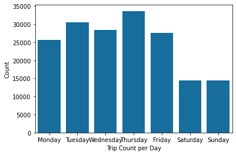

```python
# What is the trip distribution within the month of february per day?
base_color = sb.color_palette('colorblind')[0]

days = ['Monday', 'Tuesday', 'Wednesday', 'Thursday', 'Friday', 'Saturday', 'Sunday']
dayCategory = pd.api.types.CategoricalDtype(ordered=True, categories=days)
tripsData['start_day'] = tripsData['start_day'].astype(dayCategory)

sb.countplot(data=tripsData, x='start_day', color=base_color)
plt.xlabel('Trip Count per Day')
plt.ylabel('Count')
```

Based on this plot it is evident that Thursday receives the highest amount of trips while Saturday and Sunday only receive about 15K trips on average.

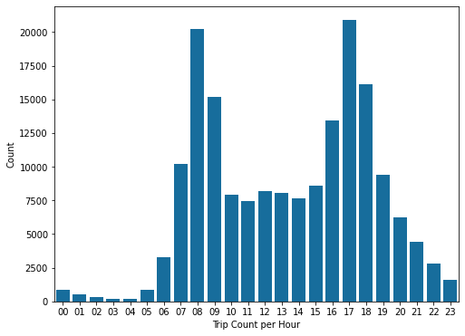

```python
# What is the trip distribution per starting hour?
plt.rcParams['figure.figsize'] = 8, 6
sb.countplot(data=tripsData, x='start_hour', color=base_color, order=tripsData['start_hour'].value_counts().index.sort_values())
plt.xlabel('Trip Count per Hour')
plt.ylabel('Count')
```

Based on the plot above, we see that usage of the bikes peaks at 8:00 am and 5:00 pm. Which coincides with the common working day for most people, commuting around 8:00 am to work and returning home around 5:00 pm.

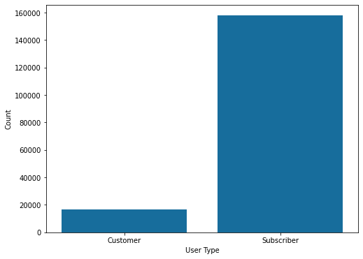

```python
# What is the distribution of trips per user type?
sb.countplot(data=tripsData, x='user_type', color=base_color)
plt.xlabel('User Type')
plt.ylabel('Count')
```

This plot shows that majority of the users taking trips happen to also be subscribers to the service.

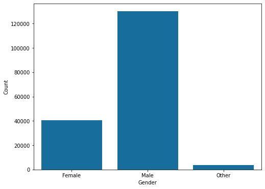

```python
# What is the distribution of trips per gender?
sb.countplot(data=tripsData, x='member_gender', color=base_color)
plt.xlabel('Gender')
plt.ylabel('Count')
```

Based on the plot, men are the primary users of the bike service within the region assessed.

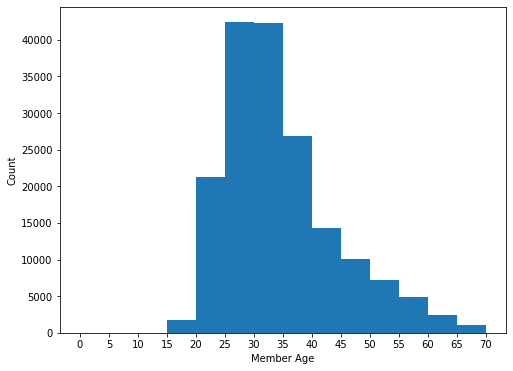

```python
# What is the distribution of trips per age?
bins = np.arange(0, tripsData['member_age'].max()+5, 5)
plt.hist(data=tripsData, x='member_age', bins=bins)
plt.xticks(bins, bins)
plt.xlabel('Member Age')
plt.ylabel('Count')
```

This reflect that the service is majorly used by people in their late twenties and early thirties.

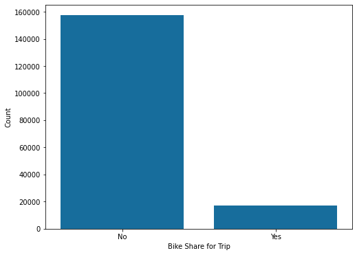

```python
# What is the distribution of trips per bike share?
sb.countplot(data=tripsData, x='bike_share_for_all_trip', color=base_color)
plt.xlabel('Bike Share for Trip')
plt.ylabel('Count')
```

The bike share package seems to be rarely used by the users of the service, with majority opting out of this. I would go as far as proposing that this is due to the fear that the bikes would be returned in a state that the users wouldn't appreciate as well as the preference of having a personal bike.

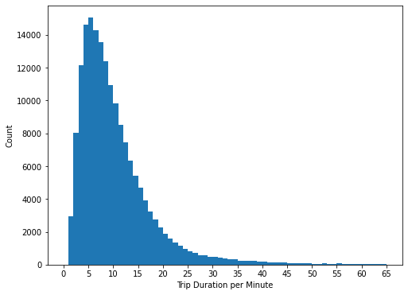

```python
# What is the trip duration distribution?
bins = np.arange(0, 66, 1)
ticks = np.arange(0, 66, 5)
plt.hist(data=tripsData, x='duration_minute', bins=bins)
plt.xticks(ticks, ticks)
plt.xlabel('Trip Duration per Minute')
plt.ylabel('Count')
```

This plot highlights how most trips were short in terms of the time taken. We may assume that the distance for these trips in particular wasn't long either as well as most user may have lived close to their destinations or have a bike station close to their destinations.

### Discuss the distribution(s) of your variable(s) of interest. Were there any unusual points? Did you need to perform any transformations?

> The distribution of the variables of interest reflected as follows: Most user were subscribers to the service and happened to be male. The usage was highest on weekdays with Thursday being the highest. The hours of 7:00 am to 9:00 am and 4:00 pm to 6:00 pm reflected the highest peaks of usage of the service on a given day. Majority of the users were middle aged users around the range of 25 to 40 years with a peak around the thirties. Most trips were short duration trips with the peak being around 4 minutes to 15 minutes.

### Of the features you investigated, were there any unusual distributions? Did you perform any operations on the data to tidy, adjust, or change the form of the data? If so, why did you do this?

> Most of the distributions fed into each other in that their results reflected towards a common picture. The picture painted, based on the distributions and my own inferences, was that most of the users were subscribers, mostly male, who used the service on weekdays (mon to fri) so we may infer it was to go to work given that their usage matches general work entry times of around 8:00 am and exit times of around 5:00 pm. We may also infer that given that bike share wasn't as popular, most users preferred having personal bikes within the service. Given the time duration in minutes we may infer that the destinations were of a close proximity to each other (relatively close given use of a bike).

## Bivariate Exploration

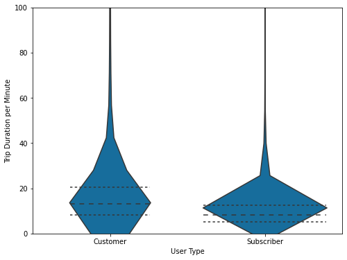

```python
# What is the variation of trip count per user type
yValue = tripsData['duration_minute']
sb.violinplot(data=tripsData, x='user_type', y=yValue, color=base_color, inner='quartile')
plt.ylim(0, 100)
plt.xlabel('User Type')
plt.ylabel('Trip Duration per Minute')
```

Customers seem to have fewer trips but more longer duration trips compared to subscribers. This suggests that customers who tend to use the service without frequency seem to have more varied trips compared to subscribers that almost seem to repeat their trips based on the majority of their trips being within 5 to 20 minutes.

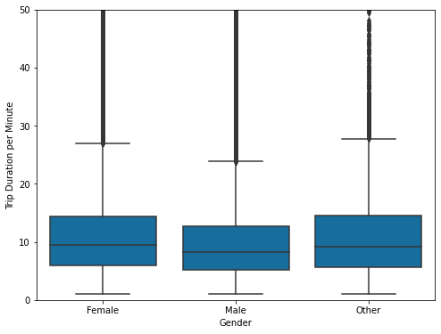

```python
# What is the variation of trip distribution based on gender?
sb.boxplot(data=tripsData, x='member_gender', y='duration_minute', color=base_color)
plt.ylim(0, 50)
plt.xlabel('Gender')
plt.ylabel('Trip Duration per Minute')
```

This chart shows that men have shorter duartion trips compared to women and those who opted not to specify.

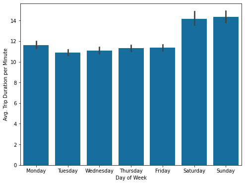

```python
# What is the distribution of trip duration over the days of the week?
sb.barplot(data=tripsData, x='start_day', y='duration_minute', color=base_color)
plt.xlabel('Day of Week')
plt.ylabel('Avg. Trip Duration per Minute')
```

The most present characteristic of this plot is that the weekend (Saturday and Sunday) have longer average duration trips. We may infer that this is due to it being a none working/free day for most thus allowing leisure trips.

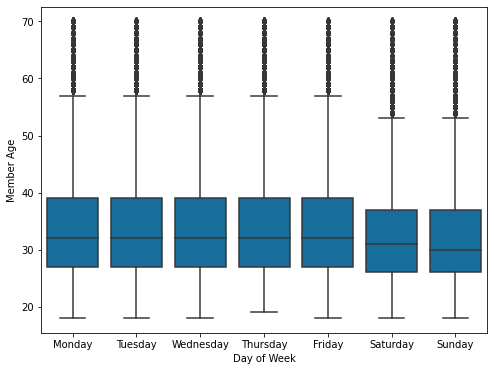

```python
# What is the distribution of member age usage over the days of the week?
sb.boxplot(data=tripsData, x='start_day', y='member_age', color=base_color)
plt.xlabel('Day of Week')
plt.ylabel('Member Age')
```

This plot shows that the age of the members is nearly consistent across the weekdays however the weekend the age drops. We may infer from this that a number of members don't use the service during the weekends between the ages of 40 and 37. While the more younger members use the service around the 27 years old over the weekend.

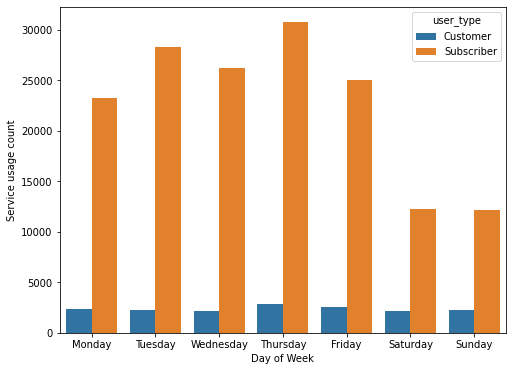

```python
# What is the distribution of customer usage versus subscriber usage?
sb.countplot(data=tripsData, x='start_day', hue='user_type')
plt.xlabel('Day of Week')
plt.ylabel('Service usage count')
```

There is a major difference in the chart above between the user types. This is the expected difference as from the preceding plots we have seen that subscribers are the majority on the platform and have the higher usage count.

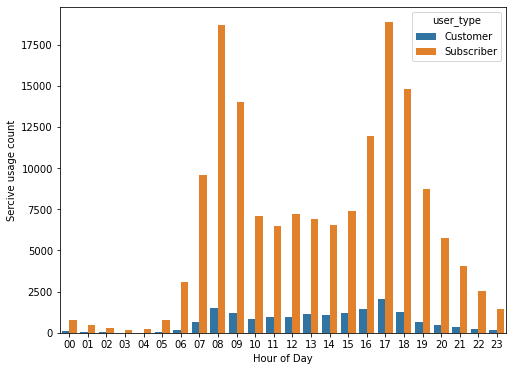

```python
# Is there a difference between the hourly usage of subscribers versus customers?
sb.countplot(data=tripsData, x='start_hour', hue='user_type', order=tripsData['start_hour'].value_counts().index.sort_values())
plt.xlabel('Hour of Day')
plt.ylabel('Sercive usage count')
```

This chart almost mirrors the usage per hour chart from the univariate exploration above, with a bias towards subscribers who are the majority when it comes to the service utilization. The customers usage also mirrors the basic trend of usage per hour only at a lower capacity.

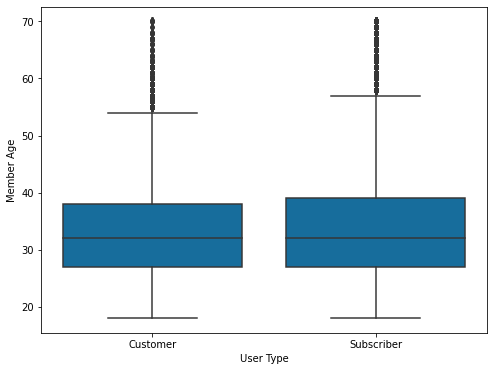

```python
# What is the member age variation of customers versus subscribers?
sb.boxplot(data=tripsData, x='user_type', y='member_age', color=base_color)
plt.xlabel('User Type')
plt.ylabel('Member Age')
```

This box plot shows how the subscriber member age holds a larger area versus customers thus informing us that not only are they more but hold a greater age range/variety.

### Did you observe any interesting relationships between the other features (not the main feature(s) of interest)?

> The general difference in usage between customers and subscribers is quite large, showing that customers may be people who don't depend on bikes as a major means of transport versus the subscribers.

## Multivariate Exploration

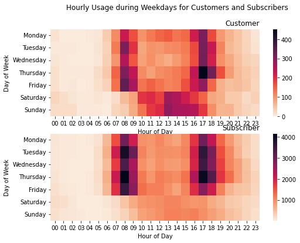

```python
# What is the distribution of hourly usage of customers compared to subscribers?
plt.suptitle('Hourly Usage during Weekdays for Customers and Subscribers')

plt.subplot(2, 1, 1)
customers = tripsData.query('user_type == "Customer"')
ct_counts = customers.groupby(['start_day', 'start_hour']).size()
ct_counts = ct_counts.reset_index(name='count')
ct_counts = ct_counts.pivot(index='start_day', columns='start_hour', values='count')
sb.heatmap(ct_counts, cmap='rocket_r')
plt.title('Customer', loc='right')
plt.xlabel('Hour of Day')
plt.ylabel('Day of Week')

plt.subplot(2, 1, 2)
subscribers = tripsData.query('user_type == "Subscriber"')
st_counts = subscribers.groupby(['start_day', 'start_hour']).size()
st_counts = st_counts.reset_index(name='count')
st_counts = st_counts.pivot(index='start_day', columns='start_hour', values='count')
sb.heatmap(st_counts, cmap='rocket_r')
plt.title('Subscriber', loc='right')
plt.xlabel('Hour of Day')
plt.ylabel('Day of Week')
```

When we go deeper in seeing the usage, this plot shows the highest amount of trips taken by subscribers were on Thursdays at 8:00 am and 5:00 pm while it is 8:00 am on Friday and 5:00 pm on Thursday for customers.

### Talk about some of the relationships you observed in this part of the investigation. Were there features that strengthened each other in terms of looking at your feature(s) of interest?

> When looking at usage of subscribers versus customers per day per hour we get to appreciate how much more in depth we are able to relay the information. Showing how on particular days during particular hours the usage varied for both demographics.

### Were there any interesting or surprising interactions between features?

> Being able to pick out the usage metrics per day per hour for the demographic and see them in form of a heatmap.